# Week 15

Kai Lukowiak

2018-05-15

# 1

Find the equation of the regression line for the given points. Round any final values to the nearest hundredth, if necessary.

( 5.6, 8.8 ), ( 6.3, 12.4 ), ( 7, 14.8 ), ( 7.7, 18.2 ), ( 8.4, 20.8 )

```r
library(tidyverse)
library(ggthemes)
X <- c(5.6, 6.3, 7, 7.7, 8.4)
y = c(8.8, 12.4, 14.8, 18.2, 20.8)
z <- rep(0, 5)
df = data_frame(X, y, z)
```

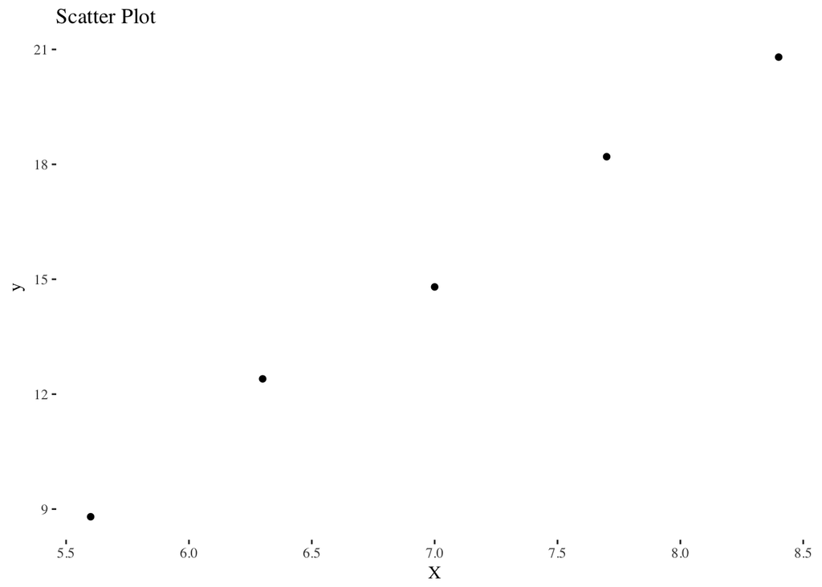

```r
ggplot(data = df, aes(x=X, y=y)) +
  geom_point() +
  theme_tufte() +
  ggtitle('Scatter Plot')
```

```r
mod = lm(y ~ X, data = df)
sum1 <- summary(mod)
ans1 <- sum1$coefficients[1]
```

The answer is -14.8.

#2 Find all local maxima, local minima, and saddle points for the function given below. Write your answer(s) in the form ( x, y, z ). Separate multiple points with a comma.

$$f(x,y) = 24x-6xy^2 -8y^3
\\
\frac{\partial f}{\partial x}=24 - 6y^2
\\
\frac{\partial f}{\partial y}=-12xy-24y^2$$

Now we must find where both partials are equal to zero. For x:

$$24-6y^2=0
\\
4-y^2=0
\\
y^2=4
\\
y = (2, \quad -2)$$

For y:

$$-12xy-24y^2=0
\\
xy-2y^2=0
\\
xy=2y^2
\\
x=2y$$

Now plug in the values from the partial WRT x:

$$y=(2,-2)
\\
x=2y
\\
x=(4,-4)$$

Thus the cirtical points (inflection) points are:

# 3

A grocery store sells two brands of a product, the “house” brand and a “name” brand. The manager estimates that if she sells the “house” brand for x dollars and the “name” brand for y dollars, she will be able to sell $81- 21x + 17y$ units of the “house” brand and $40 + 11x - 23y$ units of the “name” brand.

Find the revenu function and the revenue at x=2.3 and y = 4.1 First we need to multiply each equation by the variable that it represents:

```r
x = 2.3
y = 4.1
81 * x - 21* x^2 + 28 *y*x + 40*y  - 23*y^2
```

```
## [1] 116.62
```

# 4

A company has a plant in Los Angeles and a plant in Denver. The firm is committed to produce a total of 96 units of a product each week. The total weekly cost is given by $C(x, y) = \frac{1}{6} x^2 + \frac{1}{6} y^2 + 7x + 25y + 700$, where x is the number of units produced in Los Angeles and y is the number of units produced in Denver. How many units should be produced in each plant to minimize the total weekly cost?

This can be written as a univariate function because $x=96-y$

Costs are minimized when $C'(y)=0$

$$\frac{2}{3}y - 14=0
\\
\frac{2}{3}y =14
\\
y =21
\\
\therefore
\\
x = 96-21=75$$

# 5

Evaluate the double integral on the given region.
$$\int \int (e^{8x+3y}dA);\quad R:2 \leq x \leq 4 \quad \&\quad \leq y \leq 4$$

Write your answer in exact form without decimals.

$$\int_2 ^4 \int_2 ^4 (e^{8x+3y}dx dy)
\\
= \int_2 ^4 \frac{1}{3}e^{8x+3y}|_2^4 dx
\\
= \int_2 ^4 (\frac{1}{3}e^{8x+12}) - (\frac{1}{3}e^{8x+6}) dx
\\
= (\frac{1}{24}e^{8x+12}) - (\frac{1}{24}e^{8x+6}) |_2 ^4
\\
= ((\frac{1}{24}e^{44}) - (\frac{1}{24}e^{38})) - ((\frac{1}{24}e^{28}) - (\frac{1}{24}e^{22}))
\\
= \frac{1}{24}e^{44} - \frac{1}{24}e^{38} - \frac{1}{24}e^{28} + \frac{1}{24}e^{22}
\\
= \frac{1}{24}(e^{44} - e^{38} - e^{28} + e^{22})$$